# DATS 6101 Project 1: Chicago Crime

Nathaniel Schwamm, Andrew Jones, Christopher Broll, and Toufik Bouras

16 October 2017

## Set Up

In order to dramatically reduce the speed of running this file, we loaded the data as the csv we downloaded only the first time. After that we created an RDS file contatining our data frame, and we used that for the future running of this program and our analysis. Thus, the commented out section in the beginning will need to be run once, if you do not have the RDS file alraedy created.

## Summary of Dataset

We first want to check a quick summary of the data and look at its structure. We can also print the data set in order to scroll through it quickly.

Table continues below

| ID | month | day | year |
| --- | --- | --- | --- |
| Min. : 20224 | Length:1445357 | Length:1445357 | Length:1445357 |
| 1st Qu.: 8997838 | Class :character | Class :character | Class :character |
| Median : 9595858 | Mode :character | Mode :character | Mode :character |
| Mean : 9588239 | NA | NA | NA |
| 3rd Qu.:10212389 | NA | NA | NA |
| Max. :10827874 | NA | NA | NA |
| NA | NA | NA | NA |

Table continues below

| hour_24 | hour | minute | second |
| --- | --- | --- | --- |
| Min. : 1.00 | Length:1445357 | Length:1445357 | Length:1445357 |
| 1st Qu.:10.00 | Class :character | Class :character | Class :character |
| Median :15.00 | Mode :character | Mode :character | Mode :character |
| Mean :14.48 | NA | NA | NA |
| 3rd Qu.:20.00 | NA | NA | NA |
| Max. :24.00 | NA | NA | NA |
| NA | NA | NA | NA |

Table continues below

| AM | IUCR | Primary.Type | Description |
| --- | --- | --- | --- |
| Length:1445357 | Length:1445357 | Length:1445357 | Length:1445357 |
| Class :character | Class :character | Class :character | Class :character |
| Mode :character | Mode :character | Mode :character | Mode :character |
| NA | NA | NA | NA |
| NA | NA | NA | NA |
| NA | NA | NA | NA |
| NA | NA | NA | NA |

Table continues below

| Location.Description | Arrest | Domestic | FBI.Code |
| --- | --- | --- | --- |
| STREET :327787 | Length:1445357 | Length:1445357 | Length:1445357 |
| RESIDENCE:231522 | Class :character | Class :character | Class :character |
| APARTMENT:183409 | Mode :character | Mode :character | Mode :character |
| SIDEWALK :160191 | NA | NA | NA |
| OTHER : 55321 | NA | NA | NA |
| (Other) :485497 | NA | NA | NA |
| NA’s : 1630 | NA | NA | NA |

| Index |
| --- |
| Length:1445357 |
| Class :character |
| Mode :character |
| NA |
| NA |
| NA |
| NA |

```
## 'data.frame':    1445357 obs. of  17 variables:
##  $ ID                  : int  10508693 10508695 10508697 10508698 10508699 10508702 10508703 10508704 10508709 10508982 ...
##  $ month               : chr  "05" "05" "05" "05" ...
##  $ day                 : chr  "03" "03" "03" "03" ...
##  $ year                : chr  "2016" "2016" "2016" "2016" ...
##  $ hour_24             : num  23 21 23 22 22 22 22 21 16 22 ...
##  $ hour                : chr  "11" "09" "11" "10" ...
##  $ minute              : chr  "40" "40" "31" "10" ...
##  $ second              : chr  "00" "00" "00" "00" ...
##  $ AM                  : chr  "PM" "PM" "PM" "PM" ...
##  $ IUCR                : chr  "0486" "0486" "0470" "0460" ...
##  $ Primary.Type        : chr  "BATTERY" "BATTERY" "NOISE" "BATTERY" ...
##  $ Description         : chr  "DOMESTIC BATTERY SIMPLE" "DOMESTIC BATTERY SIMPLE" "RECKLESS CONDUCT" "SIMPLE" ...
##  $ Location.Description: Factor w/ 142 levels "ABANDONED BUILDING",..: 18 112 128 124 112 128 34 113 124 128 ...
##  $ Arrest              : chr  "True" "False" "False" "False" ...
##  $ Domestic            : chr  "True" "True" "False" "False" ...
##  $ FBI.Code            : chr  "08B" "08B" "24" "08B" ...
##  $ Index               : chr  "N" "N" "N" "N" ...
```

```
## [1] "Explore the strucutre of the data"
```

|  | ID | month | day | year | hour_24 | hour | minute | second | AM | IUCR | Primary.Type | Description | Location.Description | Arrest | Domestic | FBI.Code | Index |
| --- | --- | --- | --- | --- | --- | --- | --- | --- | --- | --- | --- | --- | --- | --- | --- | --- | --- |
| 1 | 10508693 | 05 | 03 | 2016 | 23 | 11 | 40 | 00 | PM | 0486 | BATTERY | DOMESTIC BATTERY SIMPLE | APARTMENT | True | True | 08B | N |
| 2 | 10508695 | 05 | 03 | 2016 | 21 | 09 | 40 | 00 | PM | 0486 | BATTERY | DOMESTIC BATTERY SIMPLE | RESIDENCE | False | True | 08B | N |
| 3 | 10508697 | 05 | 03 | 2016 | 23 | 11 | 31 | 00 | PM | 0470 | NOISE | RECKLESS CONDUCT | STREET | False | False | 24 | N |
| 4 | 10508698 | 05 | 03 | 2016 | 22 | 10 | 10 | 00 | PM | 0460 | BATTERY | SIMPLE | SIDEWALK | False | False | 08B | N |
| 5 | 10508699 | 05 | 03 | 2016 | 22 | 10 | 00 | 00 | PM | 0820 | THEFT | $500 AND UNDER | RESIDENCE | False | True | 06 | I |
| 6 | 10508702 | 05 | 03 | 2016 | 22 | 10 | 35 | 00 | PM | 041A | BATTERY | AGGRAVATED: HANDGUN | STREET | False | False | 04B | I |
| 7 | 10508703 | 05 | 03 | 2016 | 22 | 10 | 30 | 00 | PM | 0460 | BATTERY | SIMPLE | CHA HALLWAY/STAIRWELL/ELEVATOR | False | False | 08B | N |
| 8 | 10508704 | 05 | 03 | 2016 | 21 | 09 | 30 | 00 | PM | 0460 | BATTERY | SIMPLE | RESIDENCE PORCH/HALLWAY | False | False | 08B | N |
| 9 | 10508709 | 05 | 03 | 2016 | 16 | 04 | 00 | 00 | PM | 0460 | BATTERY | SIMPLE | SIDEWALK | False | False | 08B | N |
| 10 | 10508982 | 05 | 03 | 2016 | 22 | 10 | 30 | 00 | PM | 0486 | BATTERY | DOMESTIC BATTERY SIMPLE | STREET | False | True | 08B | N |

[output cut: 990 more lines]

## Data Checks

Just to make sure there is no missing data, we can run a quick check on the data.

```
##                   ID                month                  day
##                    0                    0                    0
##                 year              hour_24                 hour
##                    0                    0                    0
##               minute               second                   AM
##                    0                    0                    0
##                 IUCR         Primary.Type          Description
##                    0                    0                    0
## Location.Description               Arrest             Domestic
##                 1630                    0                    0
##             FBI.Code                Index
##                    0                10099
```

```
## [1] "There are around 1630 criminal incidents with missing location descriptions, and there are a lot of crimes without an index classification"
```

## Descriptive Stats

Below we created simple tables to examine the frequencies of different variables of interest.

| Crime | Frequency |
| --- | --- |
| THEFT | 326967 |
| BATTERY | 261726 |
| CRIMINAL DAMAGE | 154150 |
| NARCOTICS | 134829 |
| ASSAULT | 90515 |
| OTHER OFFENSE | 87000 |
| BURGLARY | 82730 |
| DECEPTIVE PRACTICE | 74843 |
| MOTOR VEHICLE THEFT | 60426 |
| ROBBERY | 56700 |

[output cut: 22 more lines]

| Location | Frequency |
| --- | --- |
| STREET | 327787 |
| RESIDENCE | 231522 |
| APARTMENT | 183409 |
| SIDEWALK | 160191 |
| OTHER | 55321 |
| PARKING LOT/GARAGE(NON.RESID.) | 41371 |
| ALLEY | 31544 |
| RESIDENTIAL YARD (FRONT/BACK) | 30470 |
| SMALL RETAIL STORE | 28528 |
| SCHOOL, PUBLIC, BUILDING | 25851 |

[output cut: 133 more lines]

| Arrests | Frequency |
| --- | --- |
| False | 1069787 |
| True | 375570 |

| Crime | 2012 | 2013 | 2014 | 2015 | 2016 |
| --- | --- | --- | --- | --- | --- |
| THEFT | 75454 | 71524 | 61530 | 57292 | 61167 |
| BATTERY | 59132 | 54003 | 49444 | 48904 | 50243 |
| CRIMINAL DAMAGE | 35853 | 30853 | 27797 | 28669 | 30978 |
| ASSAULT | 19898 | 17971 | 16896 | 17040 | 18710 |
| DECEPTIVE PRACTICE | 13426 | 13461 | 15300 | 15365 | 17291 |
| OTHER OFFENSE | 17480 | 17984 | 16962 | 17534 | 17040 |
| BURGLARY | 22844 | 17894 | 14569 | 13183 | 14240 |
| NARCOTICS | 35486 | 34144 | 28953 | 23833 | 12413 |
| ROBBERY | 13484 | 11819 | 9798 | 9639 | 11960 |
| MOTOR VEHICLE THEFT | 16492 | 12582 | 9913 | 10076 | 11363 |

[output cut: 22 more lines]

| Index Level | 2012 | 2013 | 2014 | 2015 | 2016 |
| --- | --- | --- | --- | --- | --- |
| N | 191980 | 179810 | 165534 | 158874 | 150049 |
| I | 138781 | 122426 | 108360 | 104086 | 115358 |
|  | 4909 | 4467 | 633 | 35 | 55 |

## Graphs

We can also look at this data graphically instead of just in table format.

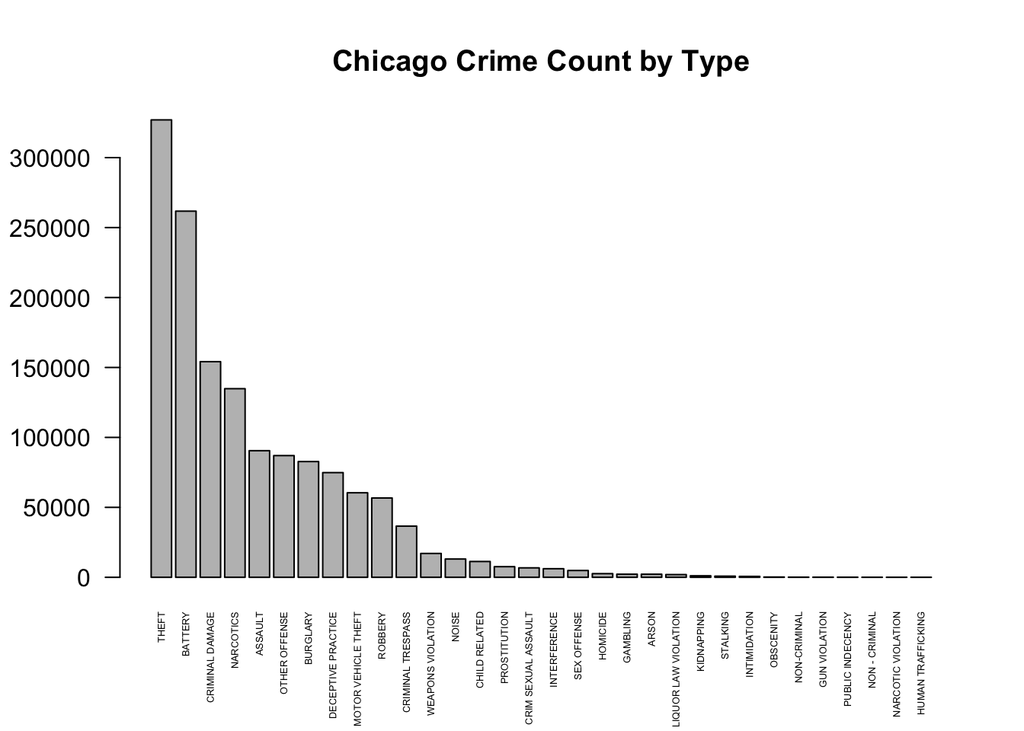

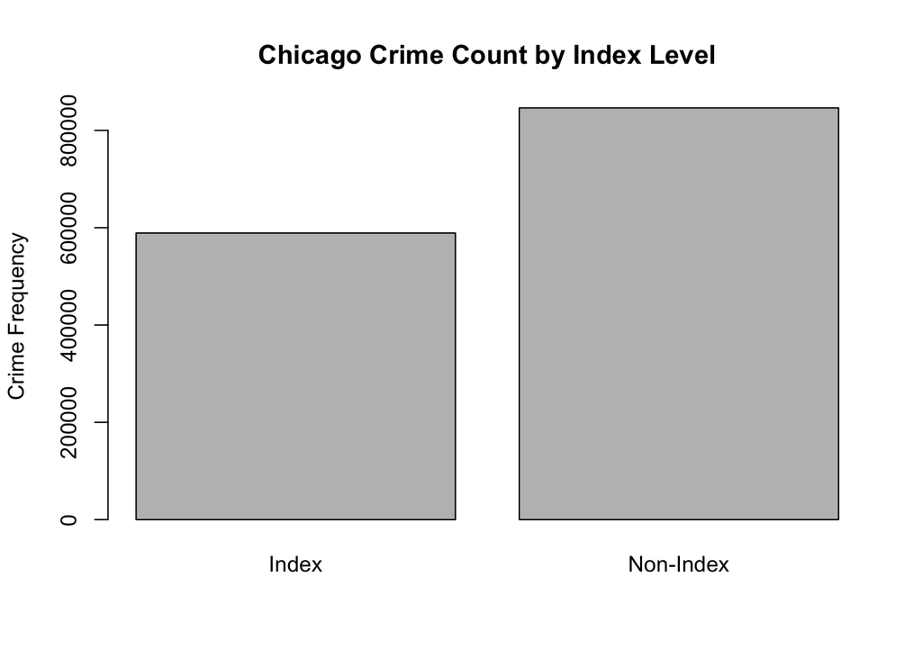

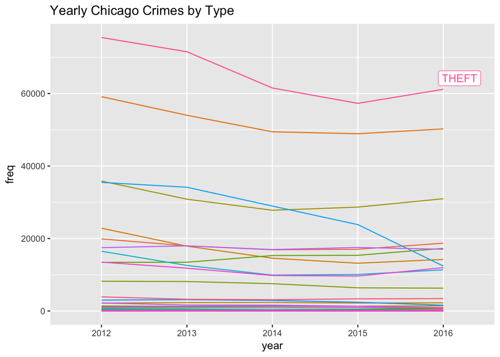

# Measures of Central Tendency and Variance

We can also calculate measures of mean and variance to give us quick summary statisics about the frequencies of different crimes by year. Using the ddply function in the plyr package allows us to do this for all of the types of crime at the same time.

| Primary.Type | y.mean | y.var | y.sd |
| --- | --- | --- | --- |
| ARSON | 441 | 3744 | 61 |
| ASSAULT | 18103 | 1548679 | 1244 |
| BATTERY | 52345 | 18371755 | 4286 |
| BURGLARY | 16546 | 15504460 | 3938 |
| CHILD RELATED | 2260 | 4959 | 70 |
| CRIM SEXUAL ASSAULT | 1352 | 5422 | 74 |
| CRIMINAL DAMAGE | 30830 | 9780493 | 3127 |
| CRIMINAL TRESPASS | 7319 | 846382 | 920 |
| DECEPTIVE PRACTICE | 14969 | 2578243 | 1606 |
| GAMBLING | 442 | 46768 | 216 |
| GUN VIOLATION | 28 | 134 | 12 |
| HOMICIDE | 524 | 20769 | 144 |
| HUMAN TRAFFICKING | 7 | 34 | 6 |
| INTERFERENCE | 1230 | 31280 | 177 |
| INTIMIDATION | 131 | 235 | 15 |
| KIDNAPPING | 219 | 471 | 22 |
| LIQUOR LAW VIOLATION | 390 | 18992 | 138 |
| MOTOR VEHICLE THEFT | 12085 | 7235902 | 2690 |
| NARCOTIC VIOLATION | 6 | 6 | 2 |
| NARCOTICS | 26966 | 87416938 | 9350 |
| NOISE | 2614 | 392701 | 627 |
| NON - CRIMINAL | 10 | 58 | 8 |
| NON-CRIMINAL | 19 | 332 | 18 |
| OBSCENITY | 37 | 165 | 13 |
| OTHER OFFENSE | 17400 | 171714 | 414 |
| PROSTITUTION | 1520 | 263496 | 513 |
| PUBLIC INDECENCY | 12 | 10 | 3 |
| ROBBERY | 11340 | 2620436 | 1619 |
| SEX OFFENSE | 973 | 3244 | 57 |
| STALKING | 164 | 664 | 26 |
| THEFT | 65393 | 59305232 | 7701 |
| WEAPONS VIOLATION | 3411 | 90311 | 301 |

# Chi-Squared Testing

For the testing section of our analysis, we performed two levels of chi-squared testing for all three of the temporal factors. First, we performed a goodness of fit test. We chose a goodness of fit, testing a model of equal frequencies (by year, month, or hour) over an ANOVA test, because we were specifically looking at the causal qualitative variable of the temporal factor and the quantaitve measure of frequency. For all of these three tests, the null hypothesis was that the distribution of the data was all equal to that model of equality. In other words, it tested whether each year represented 1/5 of the total frequency, each month represented 1/12 of the total, or each hour represented 1/24 if the total. The alternative hypothesis was the negation that the equality model was correct. The goodness-of-fit test for year was used to show there was in fact some differences in the annual crime rates, otherwise the backing for the study would be incorrect, while the tests for month and hour was used to check the hypothesis and thoughts we had going in.

The second test we performed was a chi-squared test of indepedence, where we tested for the indepedence between the temporal factor and then the severity of the crime. Because we lacked a lot of detail about the exact level of the crime, we used the Chicago crime codes matched with their definition of FBI index crimes to use “index crimes” to be crimes of higher severity. Index crimes are the eight crimes the FBI combines to produce its annual crime index which was necessary for comparison purposes between states. This was the best estimate of serious and non-serious or violent and non-violent crimes, however the comparison to this as severity is not perfect. However, for all three temporal factors, we wanted to see how that factor interplayed with the severity of the crimes. For all of these tests, the null hypothesis was that the factors were independent, and the alternative hypothesis was that they were depedent.

The results of the two tests for year are displayed below.

#### Year

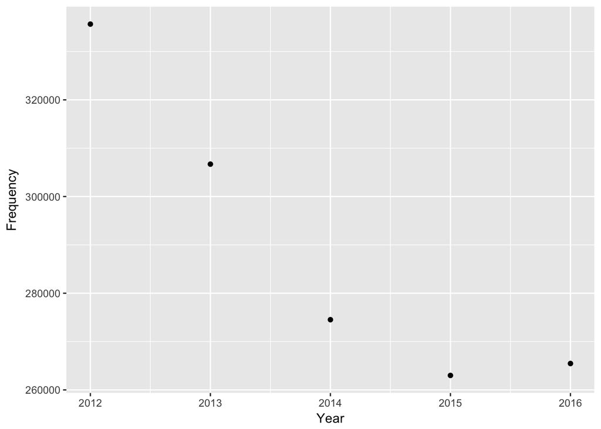

Chi-squared test for given probabilities: `Year_Count$freq`

| Test statistic | df | P value |
| --- | --- | --- |
| 13599 | 4 | 0 * * * |

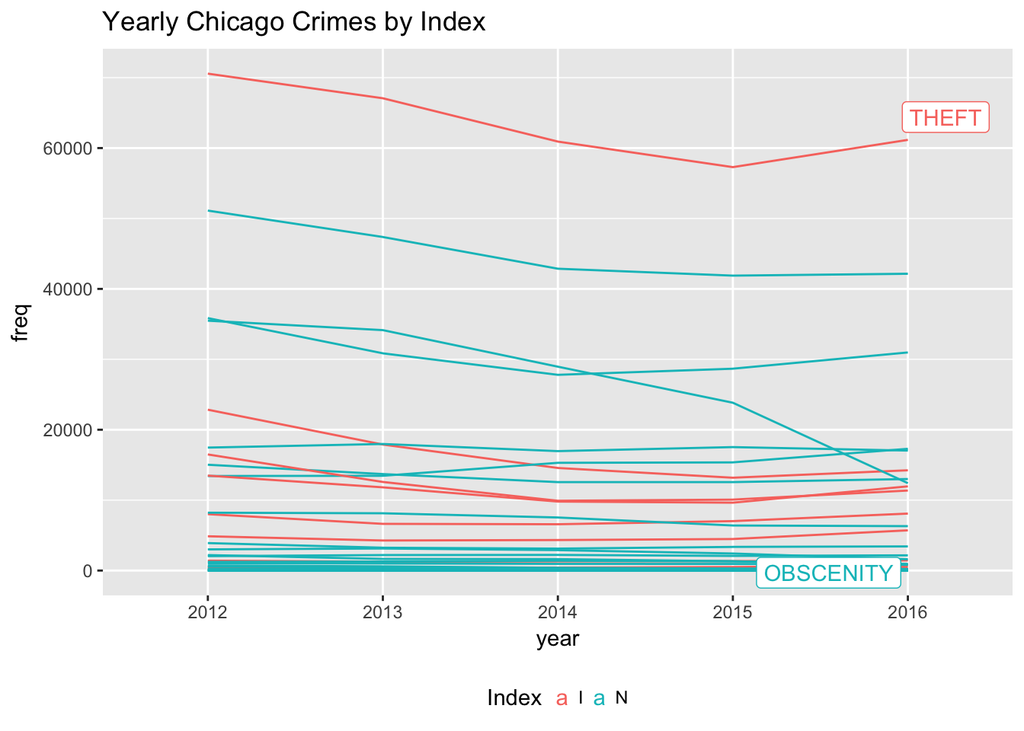

```
##    year Index   freq
## 1  2012     I 138781
## 2  2012     N 191980
## 3  2013     I 122426
## 4  2013     N 179810
## 5  2014     I 108360
## 6  2014     N 165534
## 7  2015     I 104086
## 8  2015     N 158874
## 9  2016     I 115358
## 10 2016     N 150049
```

Pearson’s Chi-squared test: `Year_Index_test_ind`

| Test statistic | df | P value |
| --- | --- | --- |
| 1273 | 4 | 1.926e-274 * * * |

We can clearly see the significance of both tests on year. This means we have reasons to reject both null hypothesis at an extremly high significance level. We can assume that crime rates have changed year to year and that change has been different for index and non-index crimes.

We can do the same analysis for monthly variation.

#### Month

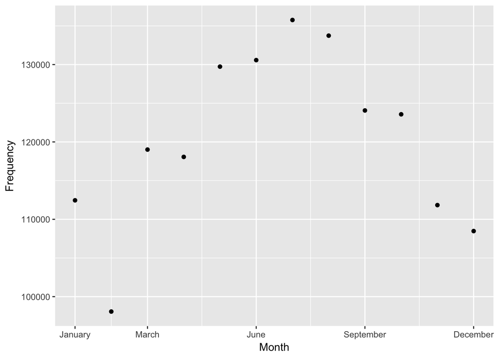

Chi-squared test for given probabilities: `Month_Count$freq`

| Test statistic | df | P value |
| --- | --- | --- |
| 11728 | 11 | 0 * * * |

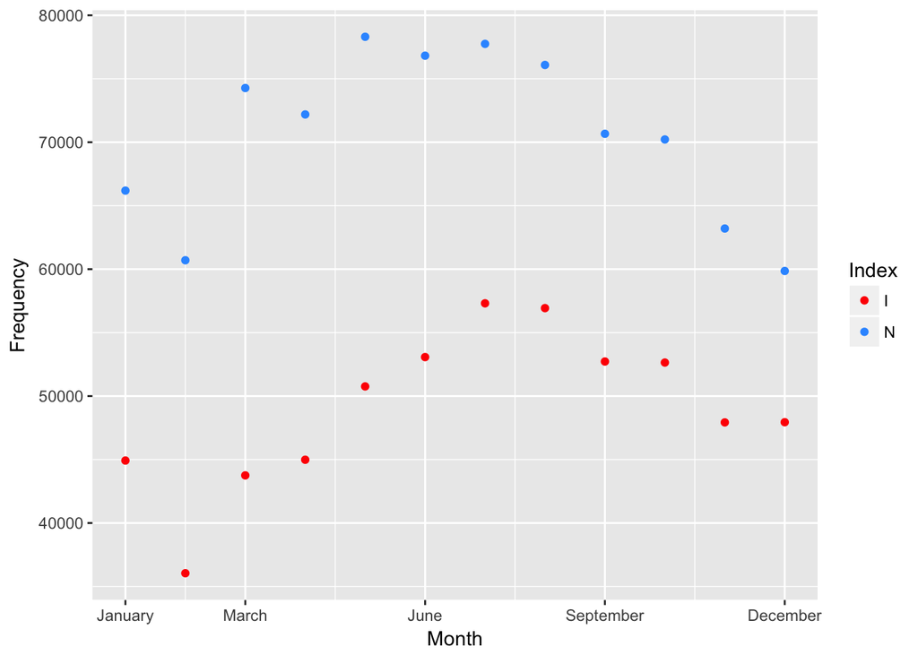

Pearson’s Chi-squared test: `Month_Index_test_ind`

| Test statistic | df | P value |
| --- | --- | --- |
| 3170 | 11 | 0 * * * |

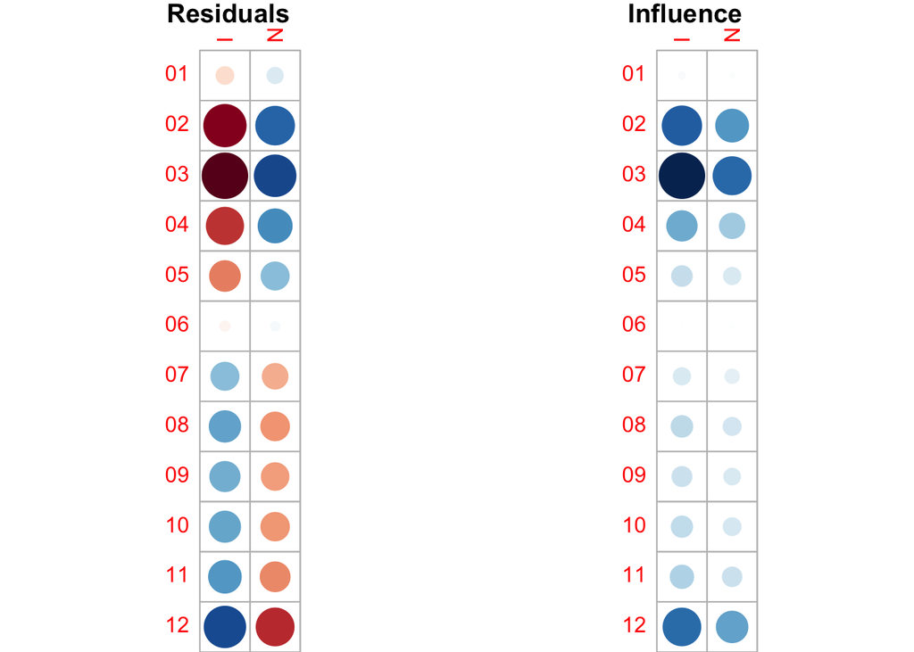

Like year, we see very signficant results that can lead us to reject the null hypothesis for both tests. This would follow along with the topic literature because we can see that there are seasonal spikes in the summer. Furthermore, we can see that the severity of crime interacts with these seasonal affects. When we look at the residuals and the influence of the different months on the chi-squared value, it is clear that the dips in the early months appear to differ the most from their expected values. This may relate to Hird’s analysis that differnt types of crime take this seasonality affect in different directions.

#### Hour

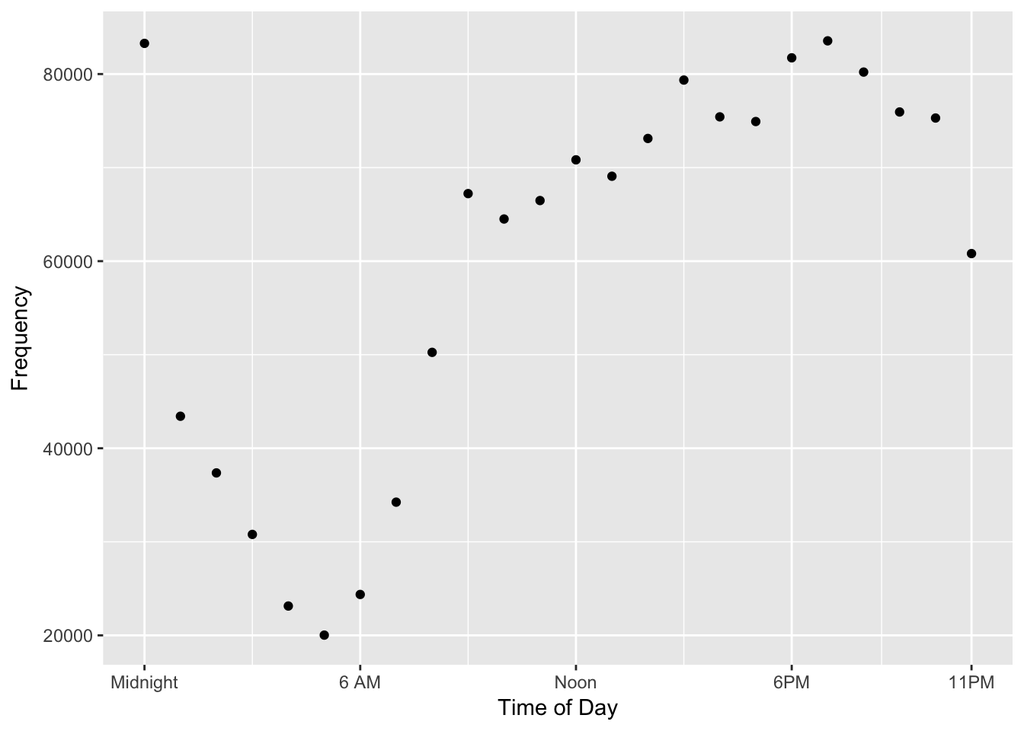

Chi-squared test for given probabilities: `Time_Count$freq`

| Test statistic | df | P value |
| --- | --- | --- |
| 172880 | 23 | 0 * * * |

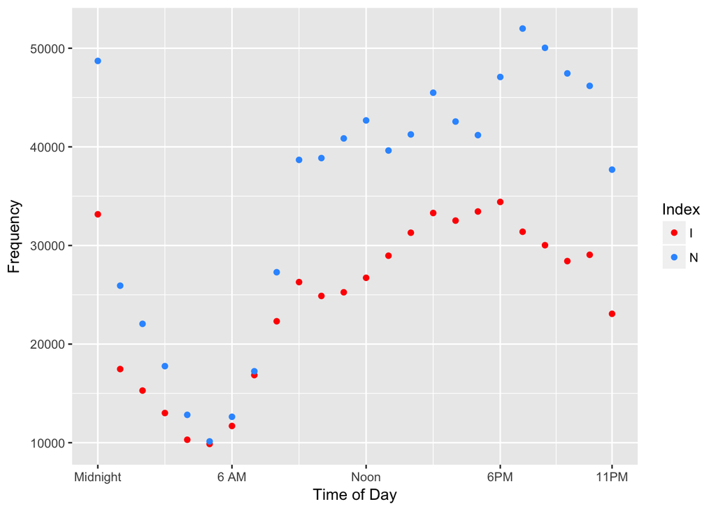

Pearson’s Chi-squared test: `Time_Index_test_ind`

| Test statistic | df | P value |
| --- | --- | --- |
| 5558 | 23 | 0 * * * |

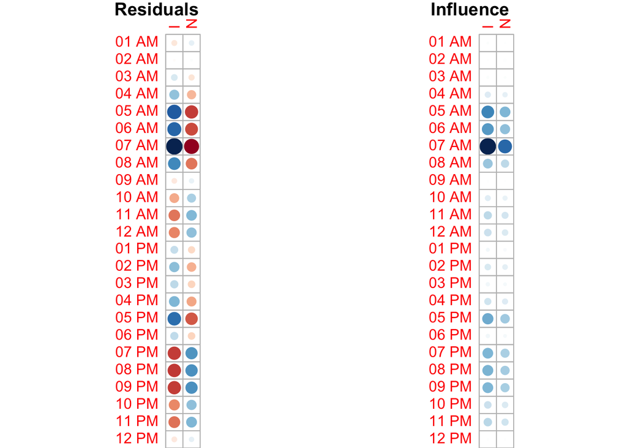

Like both year and month, we see very signficant results from hour that can lead us to reject the null hypothesis for both tests. This would follow along with the topic literature because we can see that there are hourly spikes at night approaches that dips when people start to fall asleep. Furthermore, we can see that the severity of crime interacts with this effect. When we look at the residuals and the influence of the different hours of the day, it shows that the early morning dip seems to be responsbile for a large relative portion of the chi-squared score. Comparising this with the graph we see that index and non-index crimes fall to a relatively similar value, even when non-index crimes signifcantly outpace index crimes for the rest of the day. This is probably an indicator that the effect of people going to bed may be more powerful than the depdendence of time and crime severity.

## Conclusion

Throughout this process, we have analyzed two types factors impacting crime frequency in Chicago (temporal factors and crime severity). Utilizing the exploratory process, we were able to narrow and specify our research question, and begin to develop ways to discover an answer. We display partial results here.We explore in more detail the relationship between these temporal factors, crime severity, and crime frequency in our paper.